# Nekilnojamojo turto objektų kainų analizė Lietuvoje

Statistikos laboratorinis darbas Nr. 2

VU

2025-04-17

# Įvadas

Šiame tyrime analizuojami Lietuvos nekilnojamojo turto rinkos duomenys, siekiant nustatyti įvairius dėsningumus ir statistines priklausomybes.

# Duomenų aprašymas

Analizei naudojami duomenys buvo atsisiųsti iš [Lithuanian Real Estate Listings](https://github.com/valdas-v1/lithuanian-real-estate-listings) GitHub repozitorijos. Duomenys buvo surinkti 2024 m. vasarį iš [Aruodas.lt](https://www.aruodas.lt/) puslapio. Duomenų rinkinyje yra informacija apie parduodamus ir nuomojamus butus, garažus, namus, sklypus ir patalpas. Tyrime naudojami duomenys apima kainų, ploto, vietos ir kitų svarbių charakteristikų informaciją.

## Duomenų nuskaitymas

```r
# Duomenų vieta
data_dir <- "C:/Users/zabit/Documents/GitHub/Statistikos-lab-2/data"

# Gauname aplankų pavadinimus
folders <- list.dirs(data_dir, full.names = FALSE, recursive = FALSE)

# Atspausdiname visų aplankų pavadinimus
kable(data.frame(Kategorijos = folders),
      caption = "Nekilnojamojo turto duomenų kategorijos") %>%
  kable_styling(bootstrap_options = c("striped", "hover", "condensed"))
```

Nekilnojamojo turto duomenų kategorijos

| Kategorijos |
| --- |
| apartments |
| apartments_rent |
| garages_parking |
| garages_parking_rent |
| house_rent |
| houses |
| land |
| land_rent |
| premises |
| premises_rent |

```r
# CSV failų nuskaitymas į sąrašą
csv_data_list <- list()

for (folder in folders) {
  file_path <- file.path(data_dir, folder, "all_cities_20240214.csv")
  if (file.exists(file_path)) {
    df <- read.csv(file_path)
    csv_data_list[[folder]] <- df
  }
}
```

## Duomenų patikrinimas ir išskirčių šalinimas

Prieš pradedant statistinę analizę, būtina identifikuoti ir pašalinti galimai klaidingas ar nekorektiškas reikšmes duomenyse. Nekilnojamojo turto rinkoje egzistuoja neįprastai didelių ar mažų kainų, kurios gali atsirasti dėl duomenų įvedimo klaidų, klaidingo formato ar kitų priežasčių. Tokios išskirtys gali reikšmingai paveikti statistinės analizės rezultatus.

```r
# Apibrėžiame kainų ribas išskirčių identifikavimui
min_threshold <- 20          # Minimali kaina eurais
max_threshold <- 25000000    # Maksimali kaina eurais

# Sukuriame rezultatų lentelę
removal_results <- data.frame(
  Kategorija = character(),
  Pašalinta_eilučių = integer(),
  Per_didelės_kainos = integer(),
  Per_mažos_kainos = integer(),
  stringsAsFactors = FALSE
)

# Tikriname ir šaliname išskirtis kiekviename duomenų rinkinyje
for (type in names(csv_data_list)) {
  if (!is.null(csv_data_list[[type]]) && "price" %in% colnames(csv_data_list[[type]])) {
    # Identifikuojame kraštutines reikšmes
    extreme_high <- sum(csv_data_list[[type]]$price > max_threshold, na.rm = TRUE)
    extreme_low <- sum(csv_data_list[[type]]$price < min_threshold, na.rm = TRUE)
    extreme_total <- extreme_high + extreme_low

    if (extreme_total > 0) {
      # Išsaugome pradinį eilučių skaičių
      original_count <- nrow(csv_data_list[[type]])

      # Filtruojame duomenis, išlaikydami tik patikimas kainas arba NA reikšmes
      csv_data_list[[type]] <- csv_data_list[[type]][
        (csv_data_list[[type]]$price >= min_threshold &
         csv_data_list[[type]]$price <= max_threshold) |
          is.na(csv_data_list[[type]]$price), ]

      # Fiksuojame rezultatus
      new_count <- nrow(csv_data_list[[type]])
      removed_count <- original_count - new_count

      # Pridedame rezultatus į suvestinę
      removal_results <- rbind(removal_results, data.frame(
        Kategorija = type,
        Pašalinta_eilučių = removed_count,
        Per_didelės_kainos = extreme_high,
        Per_mažos_kainos = extreme_low
      ))
    }
  }
}

# Atvaizduojame išskirčių šalinimo rezultatus
if (nrow(removal_results) > 0) {
  kable(removal_results,
        caption = "Išskirčių šalinimo rezultatų suvestinė") %>%
    kable_styling(bootstrap_options = c("striped", "hover", "condensed"))
}
```

Išskirčių šalinimo rezultatų suvestinė

| Kategorija | Pašalinta_eilučių | Per_didelės_kainos | Per_mažos_kainos |
| --- | --- | --- | --- |
| land_rent | 2 | 0 | 2 |
| premises | 65 | 64 | 1 |
| premises_rent | 192 | 159 | 33 |

```r
# Patikriname duomenų rinkinių dydžius po valymo
data_sizes <- data.frame(
  Eilučių_skaičius = sapply(csv_data_list, nrow),
  Stulpelių_skaičius = sapply(csv_data_list, ncol)
)

kable(data_sizes,
      caption = "Duomenų rinkinių dydžiai po išskirčių šalinimo") %>%
  kable_styling(bootstrap_options = c("striped", "hover", "condensed"))
```

Duomenų rinkinių dydžiai po išskirčių šalinimo

|  | Eilučių_skaičius | Stulpelių_skaičius |
| --- | --- | --- |
| apartments | 7721 | 38 |
| apartments_rent | 3208 | 38 |
| garages_parking | 497 | 28 |
| garages_parking_rent | 307 | 27 |
| house_rent | 310 | 40 |
| houses | 7284 | 39 |
| land | 6322 | 27 |
| land_rent | 102 | 27 |
| premises | 1491 | 37 |
| premises_rent | 2547 | 37 |

Pašalintos ekstremalios kainos, kurios galėjo iškreipti vidutines reikšmes ir kitas statistines charakteristikas.

```r
# Sukuriame lentelę su stulpelių sąrašais kiekvienam duomenų rinkiniui
columns_by_dataset <- data.frame(
  Duomenų_rinkinys = character(),
  Stulpelių_skaičius = integer(),
  Stulpelių_pavadinimai = character(),
  stringsAsFactors = FALSE
)

# Pildome lentelę informacija apie stulpelius
for (folder_name in names(csv_data_list)) {
  columns_by_dataset <- rbind(columns_by_dataset, data.frame(
    Duomenų_rinkinys = folder_name,
    Stulpelių_skaičius = ncol(csv_data_list[[folder_name]]),
    Stulpelių_pavadinimai = paste(colnames(csv_data_list[[folder_name]]), collapse = ", ")
  ))
}

# Atvaizduojame lentelę su stulpelių informacija
kable(columns_by_dataset,
      caption = "Kiekvieno duomenų rinkinio stulpelių struktūra") %>%
  kable_styling(bootstrap_options = c("striped", "hover", "condensed"),
                latex_options = c("scale_down", "hold_position"),
                font_size = 8) %>%
  column_spec(1, width = "8em") %>%
  column_spec(2, width = "8em") %>%
  column_spec(3, width = "32em")
```

Kiekvieno duomenų rinkinio stulpelių struktūra

| Duomenų_rinkinys | Stulpelių_skaičius | Stulpelių_pavadinimai |
| --- | --- | --- |
| apartments | 38 | listing_id, type_id, price, region, microdistrict, street, coordinates, images, description, phone_number, private_seller, call_forwarding, reserved, sold_or_rented, number_of_rooms, area, floor, no._… |
| apartments_rent | 38 | listing_id, type_id, price, region, microdistrict, street, coordinates, images, description, phone_number, private_seller, call_forwarding, reserved, sold_or_rented, price_per_month, house_no., number… |
| garages_parking | 28 | listing_id, type_id, price, region, microdistrict, street, coordinates, images, description, phone_number, private_seller, call_forwarding, reserved, sold_or_rented, area, type, accommodates_no._of_ca… |
| garages_parking_rent | 27 | listing_id, type_id, price, region, microdistrict, street, coordinates, images, description, phone_number, private_seller, call_forwarding, reserved, sold_or_rented, number, area, type, accommodates_n… |
| house_rent | 40 | listing_id, type_id, price, region, microdistrict, street, coordinates, images, description, phone_number, private_seller, call_forwarding, reserved, sold_or_rented, price_per_month, plot_area, area, … |
| houses | 39 | listing_id, type_id, price, region, microdistrict, street, coordinates, images, description, phone_number, private_seller, call_forwarding, reserved, sold_or_rented, plot_area, area, no._of_floors, bu… |
| land | 27 | listing_id, type_id, price, region, microdistrict, street, coordinates, images, description, phone_number, private_seller, call_forwarding, reserved, sold_or_rented, area_.a., purpose, type, link, add… |
| land_rent | 27 | listing_id, type_id, price, region, microdistrict, street, coordinates, images, description, phone_number, private_seller, call_forwarding, reserved, sold_or_rented, lot_no., area_.a., purpose, type, … |
| premises | 37 | listing_id, type_id, price, region, microdistrict, street, coordinates, images, description, phone_number, private_seller, call_forwarding, reserved, sold_or_rented, house_no., area, floor, no._of_flo… |
| premises_rent | 37 | listing_id, type_id, price, region, microdistrict, street, coordinates, images, description, phone_number, private_seller, call_forwarding, reserved, sold_or_rented, price_per_month, house_no., area, … |

```r
# Randame unikalius stulpelių pavadinimus visuose duomenų rinkiniuose
all_columns <- unique(unlist(lapply(csv_data_list, colnames)))
unique_columns <- sort(all_columns)

# Analizuojame stulpelių pasikartojimą skirtinguose duomenų rinkiniuose
column_presence <- data.frame(
  Stulpelis = unique_columns,
  Pasikartojimų_skaičius = sapply(unique_columns, function(col) {
    sum(sapply(csv_data_list, function(df) col %in% colnames(df)))
  }),
  stringsAsFactors = FALSE
)

# Rikiuojame pagal pasikartojimų skaičių mažėjimo tvarka
column_presence <- column_presence[order(column_presence$Pasikartojimų_skaičius, decreasing = TRUE),]

# Atvaizduojame unikalių stulpelių analizę
kable(column_presence,
      caption = paste("Unikalių stulpelių pasikartojimas duomenų rinkiniuose (iš viso:",
                      nrow(column_presence), "stulpeliai)"),
      row.names = FALSE) %>%
  kable_styling(bootstrap_options = c("striped", "hover", "condensed")) %>%
  scroll_box(width = "100%", height = "300px")
```

Unikalių stulpelių pasikartojimas duomenų rinkiniuose (iš viso: 52 stulpeliai)

| Stulpelis | Pasikartojimų_skaičius |
| --- | --- |
| add_date | 10 |
| call_forwarding | 10 |
| coordinates | 10 |
| description | 10 |
| images | 10 |
| link | 10 |
| listing_id | 10 |
| microdistrict | 10 |
| modified | 10 |
| phone_number | 10 |
| price | 10 |
| private_seller | 10 |
| region | 10 |
| reserved | 10 |
| selected | 10 |
| sold_or_rented | 10 |
| street | 10 |
| type_id | 10 |
| unique_item_number | 10 |
| valid_till | 10 |
| views_today | 10 |
| views_total | 10 |
| description_tags | 9 |
| area | 8 |
| additional_equipment | 6 |
| build_year | 6 |
| building_energy_efficiency_class | 6 |
| equipment | 6 |
| heating_system | 6 |
| house_no. | 6 |
| no._of_floors | 6 |
| security | 6 |
| additional_premises | 4 |
| building_type | 4 |
| floor | 4 |
| number_of_rooms | 4 |
| purpose | 4 |
| type | 4 |
| water_system | 4 |
| price_per_month | 3 |
| accommodates_no._of_cars | 2 |
| area_.a. | 2 |
| closest_body_of_water | 2 |
| distance_from_body_of_water | 2 |
| features | 2 |
| flat_no. | 2 |
| lot_no. | 2 |
| number | 2 |
| plot_area | 2 |
| premises_nr. | 2 |
| object | 1 |
| premises_sum | 1 |

## Duomenų vizualizacija

Grafikai padės geriau suprasti Lietuvos nekilnojamojo turto rinkos ypatybes.

```r
# Nustatome bendrą grafikų stilių
theme_scientific <- function() {
  theme_minimal() +
    theme(
      plot.title = element_text(face = "bold", size = 11),
      plot.subtitle = element_text(size = 9, color = "gray50"),
      axis.title = element_text(face = "bold", size = 10),
      axis.text = element_text(size = 9),
      legend.title = element_text(face = "bold", size = 9),
      legend.text = element_text(size = 8)
    )
}
```

### Kainų pasiskirstymo analizė

Analizuojame butų kainų pasiskirstymą, siekdami nustatyti kainų tendencijas ir išsibarstymo charakteristikas.

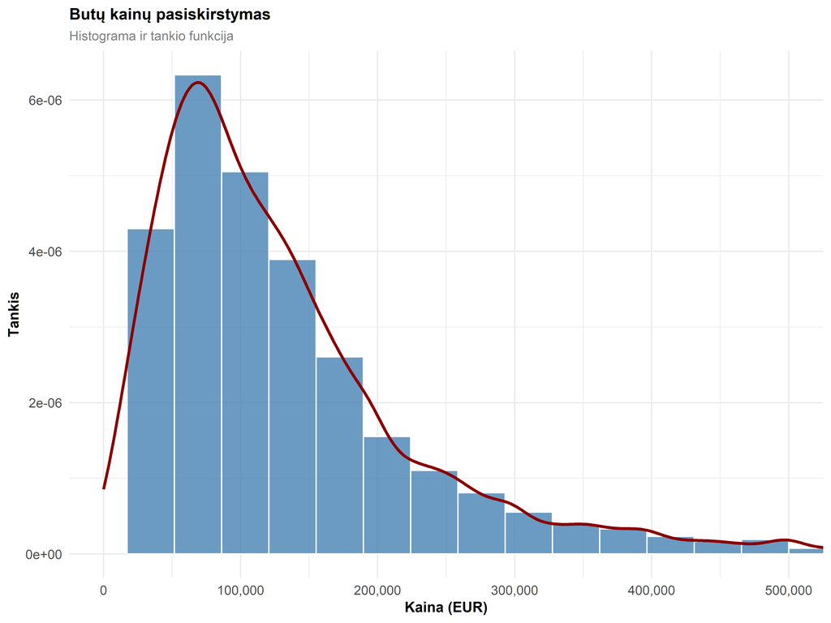

```r
# Butų kainų pasiskirstymo vizualizacija
if ("apartments" %in% names(csv_data_list) && "price" %in% colnames(csv_data_list[["apartments"]])) {
  # Pasiruošiame duomenis
  df <- data.frame(price = csv_data_list[["apartments"]]$price)

  # Braižome histogramą su tankio kreive
  price_hist <- ggplot(df, aes(x = price)) +
    geom_histogram(aes(y = after_stat(density)),
                   bins = 30,
                   fill = "steelblue",
                   color = "white",
                   alpha = 0.8) +
    geom_density(color = "darkred", linewidth = 1) +
    labs(title = "Butų kainų pasiskirstymas",
         subtitle = "Histograma ir tankio funkcija",
         x = "Kaina (EUR)",
         y = "Tankis") +
    theme_scientific() +
    scale_x_continuous(labels = comma, limits = c(0, 1000000)) +
    coord_cartesian(xlim = c(0, 500000))

  print(price_hist)
}
```

### Komercinių patalpų ploto analizė

Analizuojame komercinių patalpų ploto pasiskirstymą skirtinguose segmentuose (pardavimas ir nuoma).

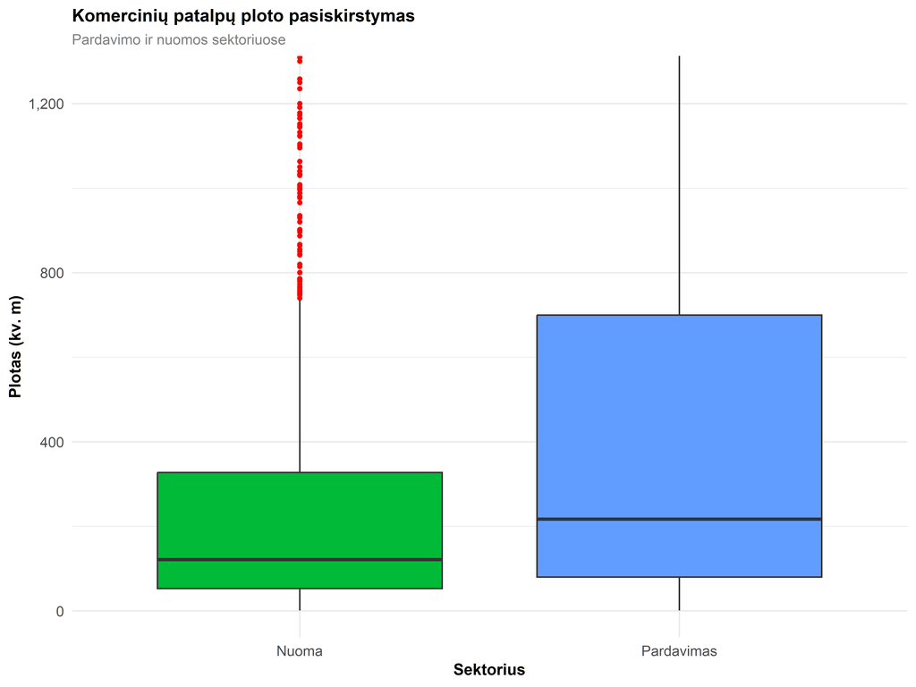

```r
# Komercinių patalpų ploto analizė
premises_types <- c("premises", "premises_rent")
premises_data <- list()

# Apjungiame duomenis iš abiejų šaltinių
for (type in premises_types) {
  if (type %in% names(csv_data_list) && "area" %in% colnames(csv_data_list[[type]])) {
    df <- csv_data_list[[type]]
    df$type <- ifelse(type == "premises", "Pardavimas", "Nuoma") # Lietuviškas žymėjimas

    # Užtikriname, kad plotas būtų skaitinis
    df$area <- as.numeric(gsub(",", ".", as.character(df$area)))

    # Atmetame nelogiškus ploto dydžius (pvz., neigiamus ar per didelius)
    df <- df[!is.na(df$area) & df$area > 0 & df$area < 10000, ]

    # Užtikriname, kad visi stulpeliai būtų vienodi abiem šaltiniam (premises ir premises_rent)
    if (length(premises_data) > 0) {
      # Nustatome bendrus stulpelius tarp esamo ir pridedamo duomenų rinkinių
      common_cols <- intersect(colnames(df), colnames(premises_data[[1]]))
      # Paliekame tik bendrus stulpelius
      df <- df[, common_cols, drop = FALSE]
    }

    premises_data[[type]] <- df
  }
}

# Sujungiame duomenis, užtikrindami stulpelių suderinamumą
if (length(premises_data) == 2) {
  # Užtikriname, kad stulpeliai abiem šaltiniuose būtų identiški
  common_cols <- intersect(colnames(premises_data[[1]]), colnames(premises_data[[2]]))
  premises_data[[1]] <- premises_data[[1]][, common_cols, drop = FALSE]
  premises_data[[2]] <- premises_data[[2]][, common_cols, drop = FALSE]
}

# Sujungiame duomenis
combined_premises <- do.call(rbind, premises_data)

# Braižome boxplot
area_boxplot <- ggplot(combined_premises, aes(x = type, y = area, fill = type)) +
  geom_boxplot(outlier.color = "red", outlier.size = 1) +
  labs(title = "Komercinių patalpų ploto pasiskirstymas",
       subtitle = "Pardavimo ir nuomos sektoriuose",
       x = "Sektorius",
       y = "Plotas (kv. m)") +
  theme_scientific() +
  theme(legend.position = "none") +
  scale_fill_manual(values = c("Pardavimas" = "#619CFF", "Nuoma" = "#00BA38")) +
  scale_y_continuous(labels = comma) +
  coord_cartesian(ylim = c(0, 1250))

print(area_boxplot)
```

### Namų nuomos kainos ryšys su plotu

Analizuojame, kaip namų nuomos kainų dydis priklauso nuo ploto.

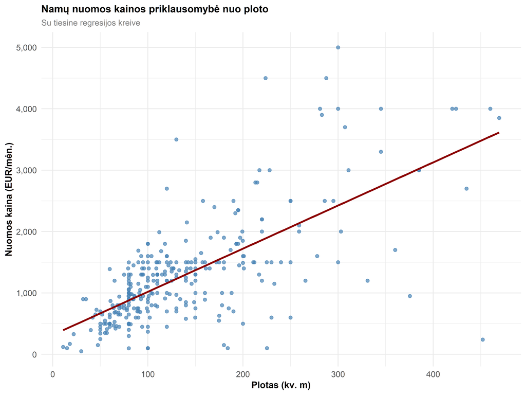

```
## Koreliacijos koeficientas tarp namų ploto ir nuomos kainos: 0.692
```

```r
# Namų nuomos kainos ir ploto priklausomybės analizė
if ("house_rent" %in% names(csv_data_list) &&
    all(c("price", "area") %in% colnames(csv_data_list[["house_rent"]]))) {

  # Pasiruošiame duomenis
  df <- csv_data_list[["house_rent"]]

  # Standartizuojame ploto stulpelį: pakeičiame kablelius taškais ir konvertuojame į skaičius
  df$area <- as.numeric(gsub(",", ".", as.character(df$area)))

  # Atmetame nelogiškas reikšmes
  df <- df[!is.na(df$area) & !is.na(df$price) &
           df$area > 0 & df$area < 500 &
           df$price > 0 & df$price < 6000, ]

  # Apskaičiuojame kainą už kvadratinį metrą
  df$price_per_sqm <- df$price / df$area
    # Braižome sklaidos diagramą su regresijos linija
  scatter_plot <- ggplot(df, aes(x = area, y = price)) +
    geom_point(alpha = 0.7, color = "steelblue") +
    geom_smooth(method = "lm", color = "darkred", se = FALSE) +
    labs(title = "Namų nuomos kainos priklausomybė nuo ploto",
         subtitle = "Su tiesine regresijos kreive",
         x = "Plotas (kv. m)",
         y = "Nuomos kaina (EUR/mėn.)") +
    theme_scientific() +
    scale_color_viridis_c() +
    scale_y_continuous(labels = comma) +
    scale_x_continuous(labels = comma)

  print(scatter_plot)

  # Pridedame koreliacijos koeficientą
  correlation <- cor(df$area, df$price, use = "complete.obs")
  cat("Koreliacijos koeficientas tarp namų ploto ir nuomos kainos:", round(correlation, 3), "\n")
}
```

# Pagrindinės skaitinės charakteristikos

## Kiekybinių kintamųjų aprašomoji statistika

Pateikiame pagrindinės skaitines charakteristikas kiekybiniams kintamiesiems.

```r
# Duomenų rinkinių filtravimas pagal stulpelio pavadinimą

filter_datasets_by_column <- function(data_list, column_name) {
  filtered <- data_list[sapply(data_list, function(df) column_name %in% colnames(df))]
  return(filtered)
}

# Statistikų skaičiavimas kintamajam
calculate_summary <- function(data_list, variable_name, target_datasets) {
  # Sukuriame tuščią rezultatų lentelę su lietuviškais pavadinimais
  results <- data.frame(
    Duomenų_rinkinys = character(),
    Vidurkis = numeric(),
    Mediana = numeric(),
    Moda = character(),
    Stand_nuokr = numeric(),
    Q1 = numeric(),
    Q3 = numeric(),
    Minimumas = numeric(),
    Maksimumas = numeric(),
    stringsAsFactors = FALSE
  )

  for (df_name in target_datasets) {
    if (df_name %in% names(data_list) && variable_name %in% colnames(data_list[[df_name]])) {
      # Išskiriame reikšmes ir konvertuojame į skaitinius duomenis
      values <- data_list[[df_name]][[variable_name]]
      numeric_values <- as.numeric(gsub(",", ".", as.character(values)))

      # Pašaliname NA reikšmes skaičiavimams
      clean_values <- numeric_values[!is.na(numeric_values)]

      if (length(clean_values) > 0) {

        # Apskaičiuojame papildomas statistikas
        mean_val <- mean(clean_values)
        median_val <- median(clean_values)
        sd_val <- sd(clean_values)
        quant_vals <- quantile(clean_values, probs = c(0.25, 0.5, 0.75))
        min_val <- min(clean_values)
        max_val <- max(clean_values)

        # Pridedame rezultatus į lentelę
        results <- rbind(results, data.frame(
          Duomenų_rinkinys = df_name,
          Vidurkis = mean_val,
          Mediana = median_val,
          Stand_nuokr = sd_val,
          Q1 = quant_vals[1],
          Q3 = quant_vals[3],
          Minimumas = min_val,
          Maksimumas = max_val
        ))
      }
    }
  }

  return(results)
}

# Apibrėžiame analizuojamus kiekybinius kintamuosius
columns_to_check <- c(
  "price", "price_per_month", "views_total", "area", "area_.a.",
  "build_year", "no._of_floors", "floor", "number_of_rooms", "plot_area"
)

# Sukuriame sąrašą rezultatams saugoti
column_results <- list()

# Apdorojame kiekvieną stulpelį ir saugome rezultatus
for (col in columns_to_check) {
  column_results[[col]] <- filter_datasets_by_column(csv_data_list, col)
}
```

```r
# Apibrėžiame duomenų rinkinio grupes
sale_datasets <- c("apartments", "garages_parking", "houses", "land", "premises")
rent_datasets <- c("apartments_rent", "house_rent", "premises_rent")
all_datasets <- c("apartments", "apartments_rent", "garages_parking", "garages_parking_rent",
                "house_rent", "houses", "land", "land_rent", "premises", "premises_rent")

sale_price_stats <- calculate_summary(csv_data_list, "price", sale_datasets)
rent_price_stats <- calculate_summary(csv_data_list, "price", rent_datasets)
views_stats <- calculate_summary(csv_data_list, "views_total", all_datasets)
floors_stats <- calculate_summary(csv_data_list, "no._of_floors", all_datasets)
rooms_stats <- calculate_summary(csv_data_list, "number_of_rooms", all_datasets)


# Atvaizduojame rezultatus lentelėse
kable(sale_price_stats,
      caption = "Pardavimų kainų statistika pagal nekilnojamojo turto tipą",
      digits = 2,
      row.names = FALSE) %>%
  kable_styling(bootstrap_options = c("striped", "hover", "condensed"))
```

Pardavimų kainų statistika pagal nekilnojamojo turto tipą

| Duomenų_rinkinys | Vidurkis | Mediana | Stand_nuokr | Q1 | Q3 | Minimumas | Maksimumas |
| --- | --- | --- | --- | --- | --- | --- | --- |
| apartments | 143718.13 | 107558 | 146129.71 | 64000 | 172000 | 43 | 2500000 |
| garages_parking | 19015.55 | 15000 | 19477.64 | 10000 | 22499 | 500 | 248000 |
| houses | 183734.43 | 140000 | 223884.94 | 55000 | 235000 | 200 | 4200000 |
| land | 115388.60 | 35000 | 386437.38 | 18000 | 79900 | 100 | 12000000 |
| premises | 413170.38 | 165000 | 762212.43 | 70000 | 399850 | 490 | 10000000 |

```r
kable(rent_price_stats,
      caption = "Nuomos kainų statistika pagal nekilnojamojo turto tipą",
      digits = 2,
      row.names = FALSE) %>%
  kable_styling(bootstrap_options = c("striped", "hover", "condensed"))
```

Nuomos kainų statistika pagal nekilnojamojo turto tipą

| Duomenų_rinkinys | Vidurkis | Mediana | Stand_nuokr | Q1 | Q3 | Minimumas | Maksimumas |
| --- | --- | --- | --- | --- | --- | --- | --- |
| apartments_rent | 609.95 | 525 | 1529.12 | 380 | 690.0 | 20 | 84900 |
| house_rent | 1428.76 | 1200 | 1327.40 | 750 | 1500.0 | 50 | 13000 |
| premises_rent | 886472.97 | 1300 | 3213628.37 | 500 | 5268.5 | 22 | 24045000 |

```r
kable(views_stats,
      caption = "Peržiūrų skaičiaus statistika pagal nekilnojamojo turto tipą",
      digits = 0,
      row.names = FALSE) %>%
  kable_styling(bootstrap_options = c("striped", "hover", "condensed"))
```

Peržiūrų skaičiaus statistika pagal nekilnojamojo turto tipą

| Duomenų_rinkinys | Vidurkis | Mediana | Stand_nuokr | Q1 | Q3 | Minimumas | Maksimumas |
| --- | --- | --- | --- | --- | --- | --- | --- |
| apartments | 1573 | 892 | 2244 | 425 | 1860 | 0 | 56297 |
| apartments_rent | 1806 | 606 | 9703 | 286 | 1315 | 2 | 355786 |
| garages_parking | 727 | 433 | 1017 | 194 | 876 | 13 | 12209 |
| garages_parking_rent | 374 | 173 | 728 | 80 | 404 | 6 | 7521 |
| house_rent | 1275 | 582 | 2332 | 262 | 1411 | 20 | 24014 |
| houses | 2247 | 1133 | 3549 | 501 | 2612 | 2 | 71418 |
| land | 869 | 346 | 2965 | 140 | 872 | 1 | 191374 |
| land_rent | 477 | 256 | 560 | 100 | 619 | 11 | 2658 |
| premises | 647 | 310 | 1296 | 132 | 710 | 0 | 21298 |
| premises_rent | 742 | 257 | 2341 | 106 | 607 | 1 | 46715 |

```r
kable(floors_stats,
      caption = "Aukštų skaičiaus statistika pagal nekilnojamojo turto tipą",
      digits = 1,
      row.names = FALSE) %>%
  kable_styling(bootstrap_options = c("striped", "hover", "condensed"))
```

Aukštų skaičiaus statistika pagal nekilnojamojo turto tipą

| Duomenų_rinkinys | Vidurkis | Mediana | Stand_nuokr | Q1 | Q3 | Minimumas | Maksimumas |
| --- | --- | --- | --- | --- | --- | --- | --- |
| apartments | 5.1 | 5 | 3.0 | 3 | 5 | 1 | 34 |
| apartments_rent | 5.3 | 5 | 3.0 | 4 | 6 | 1 | 34 |
| house_rent | 1.8 | 2 | 0.6 | 1 | 2 | 1 | 4 |
| houses | 1.6 | 2 | 0.6 | 1 | 2 | 1 | 15 |
| premises | 2.4 | 2 | 1.9 | 1 | 3 | 1 | 18 |
| premises_rent | 2.8 | 2 | 2.9 | 1 | 3 | 1 | 31 |

```r
kable(rooms_stats,
      caption = "Kambarių skaičiaus statistika pagal nekilnojamojo turto tipą",
      digits = 1,
      row.names = FALSE) %>%
  kable_styling(bootstrap_options = c("striped", "hover", "condensed"))
```

Kambarių skaičiaus statistika pagal nekilnojamojo turto tipą

| Duomenų_rinkinys | Vidurkis | Mediana | Stand_nuokr | Q1 | Q3 | Minimumas | Maksimumas |
| --- | --- | --- | --- | --- | --- | --- | --- |
| apartments | 2.4 | 2 | 1.0 | 2 | 3 | 1 | 13 |
| apartments_rent | 2.0 | 2 | 0.8 | 1 | 2 | 1 | 10 |
| house_rent | 4.2 | 4 | 1.7 | 3 | 5 | 1 | 13 |
| houses | 4.2 | 4 | 2.0 | 3 | 5 | 1 | 54 |